# HW03

# Student: Pravilov Mikhail

```python
import numpy as np
import pandas as pd
import matplotlib.pyplot as plt
from sklearn.ensemble import RandomForestClassifier
from sklearn.model_selection import train_test_split
from sklearn import svm
from sklearn.metrics import roc_curve
from sklearn.naive_bayes import GaussianNB
from scipy.stats import norm
import re
from nltk.stem import PorterStemmer
from nltk.tokenize import word_tokenize
import nltk
nltk.download('punkt')

global_random_seed = 4526
np.random.seed(global_random_seed)
dataset_root="../Datasets/"
```

# SVM

Dataset: blobs2.csv.

(3) Apply an SVM classifier (for example, from sklearn package) to blobs2.csv dataset and draw the result (both the support vectors and the separation hyperplane). Use the following kernels:

```
Linear.

Polynomial, degree 2.

Polynomial, degree 3.

Polynomial, degree 5.

Radial Basis Function.
```

Let's load blobs2.csv

```python
# blobs2.csv loading
blobs2_path = dataset_root + 'blobs2.csv'
blobs2_data = pd.read_csv(blobs2_path)
blobs2_data = blobs2_data.values
blobs2_X = blobs2_data[:, 0:-1].astype('float64')
blobs2_y = blobs2_data[:, -1]
print("blobs2 datapoints shape: " + str(blobs2_X.shape))
print("blobs2 labels shape: " + str(blobs2_y.shape))
```

```
blobs2 datapoints shape: (1000, 2)
blobs2 labels shape: (1000,)
```

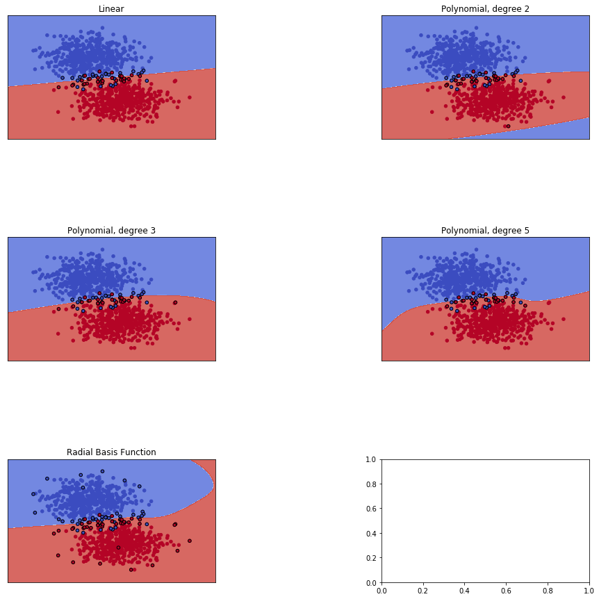

```python
def make_meshgrid(x, y, h=.02):
    x_min, x_max = x.min() - 1, x.max() + 1
    y_min, y_max = y.min() - 1, y.max() + 1
    xx, yy = np.meshgrid(np.arange(x_min, x_max, h),
                         np.arange(y_min, y_max, h))
    return xx, yy


def plot_contours(ax, clf, xx, yy, **params):
    Z = clf.predict(np.c_[xx.ravel(), yy.ravel()])
    Z = Z.reshape(xx.shape)
    out = ax.contourf(xx, yy, Z, **params)
    return out

np.random.seed(global_random_seed)
models = (svm.SVC(kernel='linear', random_state=global_random_seed),
          svm.SVC(kernel='poly', degree=2, gamma='auto', random_state=global_random_seed),
          svm.SVC(kernel='poly', degree=3, gamma='auto', random_state=global_random_seed),
          svm.SVC(kernel='poly', degree=5, gamma='auto', random_state=global_random_seed),
          svm.SVC(kernel='rbf', gamma='auto', random_state=global_random_seed)
          )
models = (clf.fit(blobs2_X, blobs2_y) for clf in models)

titles = ('Linear',
          'Polynomial, degree 2',
          'Polynomial, degree 3',
          'Polynomial, degree 5',
          'Radial Basis Function')

fig, sub = plt.subplots(3, 2, figsize=(15,15))
plt.subplots_adjust(wspace=0.8, hspace=0.8)

X0, X1 = blobs2_X[:, 0], blobs2_X[:, 1]
xx, yy = make_meshgrid(X0, X1)

for clf, title, ax in zip(models, titles, sub.flatten()):
    plot_contours(ax, clf, xx, yy,
                  cmap=plt.cm.coolwarm, alpha=0.8)
    ax.scatter(X0, X1, c=blobs2_y, cmap=plt.cm.coolwarm, s=20, edgecolors=None)
    X0_support, X1_support, y_support = X0[clf.support_], X1[clf.support_], blobs2_y[clf.support_]
    ax.scatter(X0_support, X1_support, c=y_support, cmap=plt.cm.coolwarm, s=20, edgecolors='k')
    ax.set_xlim(xx.min(), xx.max())
    ax.set_ylim(yy.min(), yy.max())
    ax.set_xticks(())
    ax.set_yticks(())
    ax.set_title(title)

plt.show()
```

Note: support vectors are bounded with black round bound

Datasets: spam.csv and cancer.csv.

(3) Apply SVM and RandomForest methods to cancer.csv and spam.csv dataset. Compare training time with close performance on validation (20%).

Let's load cancer and spam

```python
# spam.csv loading
spam_path = dataset_root + 'spam.csv'
spam_data = pd.read_csv(spam_path)
spam_data = spam_data.values
spam_X = spam_data[:, 0:-1].astype('float64')
spam_y = spam_data[:, -1]
print("spam datapoints shape: " + str(spam_X.shape))
print("spam labels shape: " + str(spam_y.shape))
```

```
spam datapoints shape: (4601, 57)
spam labels shape: (4601,)
```

```python
# cancer.csv loading
cancer_path = dataset_root + 'cancer.csv'
cancer_data = pd.read_csv(cancer_path)
cancer_data = cancer_data.values
cancer_X = cancer_data[:, 1:].astype('float64')
cancer_y = cancer_data[:, 0]
print("cancer datapoints shape: " + str(cancer_X.shape))
print("cancer labels shape: " + str(cancer_y.shape))
```

```
cancer datapoints shape: (569, 30)
cancer labels shape: (569,)
```

```python
val_size=0.2
np.random.seed(global_random_seed)
spam_X_train, spam_X_val, spam_y_train, spam_y_val = train_test_split(spam_X, spam_y,
                                                    stratify=spam_y,
                                                    random_state=global_random_seed,
                                                    test_size=val_size)
cancer_X_train, cancer_X_val, cancer_y_train, cancer_y_val = train_test_split(cancer_X, cancer_y,
                                                    stratify=cancer_y,
                                                    random_state=global_random_seed,
                                                    test_size=val_size)
```

```python
def fit_and_measure_time(clf, X_train, y_train):
    import time
    start = time.time()
    clf.fit(X_train, y_train)
    end = time.time()
    return end - start
```

```python
def get_training_time_and_acc(clf, X_train, y_train, X_val, y_val):
    return fit_and_measure_time(clf, X_train, y_train), clf.score(X_val, y_val)

def compare_svm_and_random_forest(svm, rf, X_train, y_train, X_val, y_val):
    svm_time, svm_score = get_training_time_and_acc(svm, X_train, y_train, X_val, y_val)
    rf_time, rf_score = get_training_time_and_acc(rf, X_train, y_train, X_val, y_val)
    print("===SVM===")
    print("Time: " + str(svm_time))
    print("Accuracy: " + str(svm_score))
    print("===Random Forest===")
    print("Time: " + str(rf_time))
    print("Accuracy: " + str(rf_score))
    print("===(SVM - Random Forest)===")
    print("Time: " + str(svm_time - rf_time))
    print("Accuracy: " + str(svm_score - rf_score))
```

```python
# cancer
np.random.seed(global_random_seed)
svm_clf = svm.SVC(kernel='linear', random_state=global_random_seed)
rf = RandomForestClassifier(n_estimators=10, max_depth=1)
print("Cancer dataset")
compare_svm_and_random_forest(svm_clf, rf, cancer_X_train, cancer_y_train, cancer_X_val, cancer_y_val)
```

```
Cancer dataset
===SVM===
Time: 1.4074294567108154
Accuracy: 0.956140350877193
===Random Forest===
Time: 0.008619308471679688
Accuracy: 0.9649122807017544
===(SVM - Random Forest)===
Time: 1.3988101482391357
Accuracy: -0.00877192982456143
```

Looks like on cancer SVM much slower with accuracy about 96%

```python
# spam
np.random.seed(global_random_seed)
svm_clf = svm.SVC(kernel='linear', random_state=global_random_seed)
rf = RandomForestClassifier(n_estimators=10, max_depth=13, random_state=global_random_seed)
print("Spam dataset")
compare_svm_and_random_forest(svm_clf, rf, spam_X_train, spam_y_train, spam_X_val, spam_y_val)
```

```
Spam dataset
===SVM===
Time: 169.0495309829712
Accuracy: 0.9294245385450597
===Random Forest===
Time: 0.04812788963317871
Accuracy: 0.9294245385450597
===(SVM - Random Forest)===
Time: 169.001403093338
Accuracy: 0.0
```

Here SVM is worse even more.

# Bayesian Classifier

Datasets: spam.csv and cancer.csv.

(6) Implement a Naive Bayesian Classifier with Gaussian features (no need for EM algorithm, sample mean and variance are sufficient for determining the parameters of a feature distribution) and apply it to spam.csv and cancer.csv.

Draw ROC-curves for scaled output probability (the output itself is quite small, so you should scale it in a way that sums up to 1 for a specific datapoint across all classes).

```python
def draw_roc_curve(clf, X, y, label, positive_label, positive_label_index):
    fpr, tpr, _ = roc_curve(y, clf.predict_proba(X)[:, positive_label_index], pos_label=positive_label)
    plt.plot(fpr, tpr)
    plt.title(label + " ROC curve")
    plt.show()
```

```python
def conduct_roc_curve_experiment_for_classifier(clf):
    clf.fit(cancer_X_train, cancer_y_train)
    print("Cancer Accuracy: " + str(clf.score(cancer_X_val, cancer_y_val)))
    print("Cancer 0th datapoint proba: " + str(clf.predict_proba(cancer_X_train[0].reshape(1, -1))))
    draw_roc_curve(clf, cancer_X_train, cancer_y_train, "Cancer Train", 'M', 1)
    draw_roc_curve(clf, cancer_X_val, cancer_y_val, "Cancer Test", 'M', 1)

    clf.fit(spam_X_train, spam_y_train)
    print("Spam Accuracy: " + str(clf.score(spam_X_val, spam_y_val)))
    print("Spam 0th datapoint proba: " + str(clf.predict_proba(spam_X_train[0].reshape(1, -1))))
    draw_roc_curve(clf, spam_X_train, spam_y_train, "Spam Train", 1, 1)
    draw_roc_curve(clf, spam_X_val, spam_y_val, "Spam Test", 1, 1)
```

```python
def get_class_proba(y):
    _, counts = np.unique(y, return_counts=True)
    return counts / y.shape[0]

def create_labels_mapping(y):
    classes, inverse = np.unique(y, return_inverse=True)
    real_labels_to_int = {}
    for i in range(classes.shape[0]):
        real_labels_to_int[classes[i]] = i
    return real_labels_to_int, classes, inverse

class MyGaussianNB:
    def calculate_mean_and_std(self, X, y):
        self.features_means = np.empty((self.int_to_real_labels.shape[0], X.shape[1]))
        self.features_stds = np.empty((self.int_to_real_labels.shape[0], X.shape[1]))
        for label in range(self.int_to_real_labels.shape[0]):
            features_for_label = X[y == label, :]
            self.features_means[label] = np.mean(features_for_label, axis=0)
            self.features_stds[label] = np.std(features_for_label, axis=0)

    def __init__(self):
        self.class_proba = None
        self.features_proba = None
        self.real_labels_to_int = None
        self.int_to_real_labels = None
        self.features_means = None
        self.features_stds = None

    def fit(self, X, y):
        self.real_labels_to_int, self.int_to_real_labels, y = create_labels_mapping(y)
        self.class_proba = get_class_proba(y)
        self.calculate_mean_and_std(X, y)

    def predict_proba(self, X):
        proba = np.empty((X.shape[0], self.int_to_real_labels.shape[0]))
        for label in range(self.int_to_real_labels.shape[0]):
            pdfs = np.empty(X.shape)
            for i in range(X.shape[0]):
                for j in range(X.shape[1]):
                    pdfs[i][j] = norm.pdf(X[i][j], loc=self.features_means[label][j], scale=self.features_stds[label][j])
            proba[:, label] = np.prod(pdfs, axis=1) * self.class_proba[label]
        for i in range(proba.shape[0]):
            if np.sum(proba[i]) != 0:
                proba[i] = proba[i] / np.sum(proba[i])
            else:
                proba[i] = 0.5
        return proba

    def convert_labels_to_int(self, y):
        return np.array([self.real_labels_to_int[y[i]] for i in range(y.shape[0])])

    def convert_int_to_real_labels(self, y):
        return np.array([self.int_to_real_labels[y[i]] for i in range(y.shape[0])])

    def predict(self, X):
        proba = self.predict_proba(X)
        predicted = np.argmax(proba, axis=1)
        return self.convert_int_to_real_labels(predicted)

    def score(self, X, y):
        predicted = self.predict(X)
        return (predicted == y).mean()
```

```
Cancer Accuracy: 0.9298245614035088
Cancer 0th datapoint proba: [[0.00369729 0.99630271]]
```

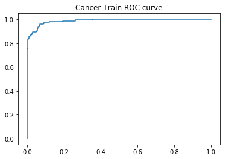

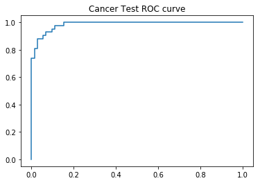

```
Spam Accuracy: 0.8262757871878393
Spam 0th datapoint proba: [[8.2483293e-206 1.0000000e+000]]
```

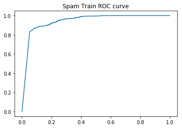

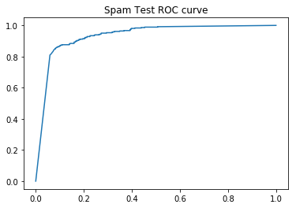

```python
conduct_roc_curve_experiment_for_classifier(MyGaussianNB())
```

Dataset: smsspam.csv

(6) Implement a Naive Bayesian Classifier with discrete features, i.e., numbers for dictionary words in the text in smsspam.csv dataset. So, if your dictionary is N words, each datapoint will have N features. Stemming is advised. Draw ROC-curves for scaled output probability.

```python
# smsspam.csv loading
smsspam_path = dataset_root + 'smsspam.csv'
smsspam_data = pd.read_csv(smsspam_path)
smsspam_data = smsspam_data.values
smsspam_X = smsspam_data[:, 1]
smsspam_y = smsspam_data[:, 0]
smsspam_y[smsspam_y == 'ham'] = 0
smsspam_y[smsspam_y == 'spam'] = 1
smsspam_y = smsspam_y.astype(int)
print("smsspam datapoints shape: " + str(smsspam_X.shape))
print("smsspam datapoints type: " + str(smsspam_X.dtype))
print("smsspam 0th datapoint: " + str(smsspam_X[0]))

print("smsspam labels shape: " + str(smsspam_y.shape))
print("smsspam datapoints type: " + str(smsspam_y.dtype))
print("smsspam 0th datapoint's label: " + str(smsspam_y[0]))
```

```
smsspam datapoints shape: (5572,)
smsspam datapoints type: object
smsspam 0th datapoint: Go until jurong point, crazy.. Available only in bugis n great world la e buffet... Cine there got amore wat...
smsspam labels shape: (5572,)
smsspam datapoints type: int64
smsspam 0th datapoint's label: 0
```

```python
val_size=0.2
np.random.seed(global_random_seed)
smsspam_X_train, smsspam_X_val, smsspam_y_train, smsspam_y_val = train_test_split(smsspam_X, smsspam_y,
                                                    stratify=smsspam_y,
                                                    random_state=global_random_seed,
                                                    test_size=val_size)
print(smsspam_X_train.shape)
print(smsspam_y_val.shape)
```

```
(4457,)
(1115,)
```

```python
def split_string_on_words(string):
    ps = PorterStemmer()
    words = word_tokenize(string)
    stemmed_words = [ps.stem(word) for word in words]
    return stemmed_words

def convert_texts_to_words_list(texts):
    return np.array([word for i in range(texts.shape[0]) for word in split_string_on_words(texts[i])])

def convert_texts_to_words_lists_for_each(texts):
    return [split_string_on_words(texts[i]) for i in range(texts.shape[0])]

def transform_text_to_frequency_map(texts, y):
    text_words = convert_texts_to_words_list(texts)
    unique_words, counts = np.unique(text_words, return_counts=True)
    most_frequent = np.argsort(counts)[-int(1 * len(counts)):]
    unique_words = unique_words[most_frequent]
    classes = np.unique(y)
    counts_for_label = np.zeros((classes.shape[0], unique_words.shape[0]))
    for i in range(counts_for_label.shape[0]):
        words_for_class = convert_texts_to_words_list(texts[y == i])
        for j in range(unique_words.shape[0]):
            counts_for_label[i][j] += np.sum(words_for_class == unique_words[j])
    ids_to_words = {unique_words[i]: i for i in range(unique_words.shape[0])}
    return ids_to_words, counts_for_label

class MyMultinomialNB:
    def fit(self, X, y):
        word_mapping, word_frequency_per_class = transform_text_to_frequency_map(X, y)
        print("Vocabulary size: " + str(len(word_mapping)))
        self.class_proba = get_class_proba(np.arange(word_frequency_per_class.shape[0]))
        self.word_frequency_per_class = word_frequency_per_class
        self.word_mapping = word_mapping

    def predict_proba(self, X):
        X = convert_texts_to_words_lists_for_each(X)
        proba = np.empty((len(X), self.class_proba.shape[0]))
        for label in range(self.class_proba.shape[0]):
            for i in range(len(X)):
                pdf = 1
                for j in range(len(X[i])):
                    if X[i][j] in self.word_mapping:
                        word_id = self.word_mapping[X[i][j]]
                        pdf *= (self.word_frequency_per_class[label][word_id] + 1) / (np.sum(self.word_frequency_per_class[label]) + len(self.word_mapping))
                proba[i, label] = pdf * self.class_proba[label]
        for i in range(proba.shape[0]):
            if np.sum(proba[i]) != 0:
                proba[i] = proba[i] / np.sum(proba[i])
            else:
                proba[i] = 0.5
        return proba

    def predict(self, X):
        proba = self.predict_proba(X)
        predicted = np.argmax(proba, axis=1)
        return predicted

    def score(self, X, y):
        predicted = self.predict(X)
        return (predicted == y).mean()
```

```python
def conduct_roc_curve_experiment_for_smsspam(clf):
    clf.fit(smsspam_X_train, smsspam_y_train)
    print("smsspam Train Accuracy: " + str(clf.score(smsspam_X_train, smsspam_y_train)))
    print("smsspam Test Accuracy: " + str(clf.score(smsspam_X_val, smsspam_y_val)))
    print("smsspam 0th datapoint proba: " + str(clf.predict_proba(np.array([smsspam_X_train[0]]))))
    draw_roc_curve(clf, smsspam_X_train, smsspam_y_train, "smsspam Train", 1, 1)
    draw_roc_curve(clf, smsspam_X_val, smsspam_y_val, "smsspam Test", 1, 1)
```

```
Vocabulary size: 7714
smsspam Train Accuracy: 0.9840700022436617
smsspam Test Accuracy: 0.97847533632287
smsspam 0th datapoint proba: [[9.99754658e-01 2.45342294e-04]]
```

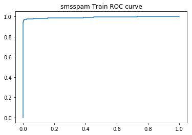

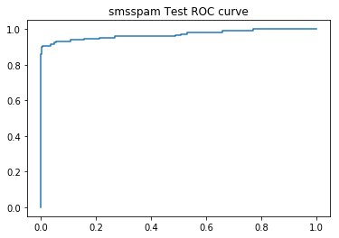

```python
conduct_roc_curve_experiment_for_smsspam(MyMultinomialNB())
```